# An Integral Projection Model for *Oenothera coloradensis* using the `ipmr` R package

Alice Stears

12/10/2021

## Background

*Oenothera coloradensis* is a monocarpic perennial herb that occurs in riparian and wetland habitats in southeast Wyoming, southwest Nebraska, and northern Colorado. It was listed as “threatened” under the Endangered Species Act until December, 2019. It was originally listed because it is naturally rare, and even though it’s ESA designation has since been removed, this species is still very uncommon. One chapter of my dissertation is using demographic methods to investigate the mechanisms that allow populations of this rare species to persist. I am building an integral projection model (IPM) for this species, and can use results from this model to test for the existence of several different persistence mechanisms.

I have three consecutive years of pre-reproductive census data for this species, which includes survival status, size (longest leaf), reproductive status, and reproductive output for each year. I also have counts of ‘seedlings’ in each year (individuals less than 3 cm in leaf length), and estimates of seed germination rate and seed vitality rate. I am working on building an IPM that includes a continuous stage for adult individuals, and two discrete stages for seedlings and the seedbank. I was able to build a test IPM using only the continuous stage by hand using code from Ellner and Rees, 2016. However, the process for creating an IPM by hand with two discrete stages as well as a continuous stage seemed daunting, so I’ve tried to use the `ipmr` package. I’ve followed the `ipmr` vignettes and was able to create a simple, continuous-only IPM in impr that returns the same results as the continuous-only IPM I built by hand. However, because the package is new and there is not a published example of an IPM with two discrete stages, I’m not as confident as I’d like that I’ve specified the general, multi-stage model correctly. I would greatly appreciate you taking a quick look at the model, and if possible confirming that I’ve specified it correctly. I’ve included a life-cycle diagram for this species, the IPM kernel functions, and code for a general, discrete IPM with one continuous and two discrete stages I’ve created using `ipmr`. This model doesn’t include density dependence and environmental co-variates, since I’ve been able to follow the `ipmr` vignettes to incorporate these elements. I’m primarily interested in confirming that I’ve written the code for the demographic functions correctly.

### *Oenothera coloradensis* life-cycle diagram

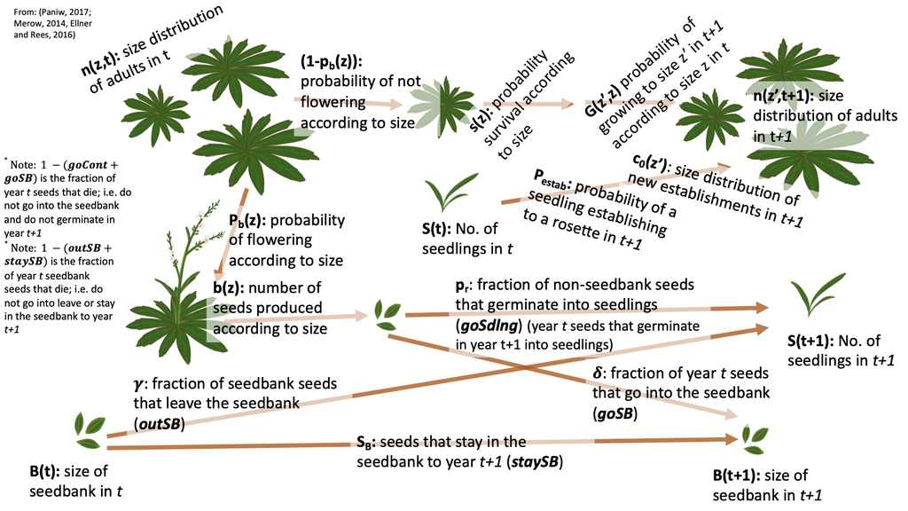

Figure of the O. coloradensis life-cycle, with transitions labeled

### Functions in the IPM kernel

**Distribution of size of individuals in year *t+1* (continuous stage):**
New recruits from the seedling stage + growth and survival kernel
$$n(z',t+1) = S(t)p_{estab}c_o(z') + \int_{L}^{U}(1-P_b(z))s(z)G(z',z)n(z,t)dz$$
**Size of the seedling stage (discrete stage):**
New seedlings that germinate out of the seedbank + new seedlings that came from seeds produced by adult plants in the previous year (i.e. seeds that skipped the seedbank)
$$S(t+1) = B(t)outSB + goSdlng\int_{L}^{U}P_b(z)b(z)n(z,t)dz$$
**Seedbank (discrete stage):**
seeds that stay in the seedbank + seeds that are added to the seedbank by seed production from adult plants
$$B(t+1) = B(t)staySB+goSB\int_{L}^{U}P_b(z)b(z)n(z,t)dz$$

### Make vital rate models

These are simple models that do not include density dependence or environmental covariates, although the final models will contain these elements.

**Load census data**

```r
# load continuous stage data
# replace this with the location of 'COBP_long_CURRENT' on your machine
fileName_1 <- "../../Processed_Data/COBP_long_CURRENT.csv"

dat <- read.csv(fileName_1)
```

**Survival ($s(z)$)**

```r
## subset the data to exclude flowering individuals
survDat <- dat[dat$flowering==0 | is.na(dat$flowering),]

## logistic glm with log-transformed size_t
survMod <- glm(survives_tplus1 ~ log_LL_t , data = survDat, family = binomial)
summary(survMod)
```

```
##
## Call:
## glm(formula = survives_tplus1 ~ log_LL_t, family = binomial,
##     data = survDat)
##
## Deviance Residuals:
##     Min       1Q   Median       3Q      Max
## -1.8139  -1.3476   0.8149   0.9412   1.2158
##
## Coefficients:
##             Estimate Std. Error z value Pr(>|z|)
## (Intercept) -0.40633    0.14271  -2.847  0.00441 **
## log_LL_t     0.53852    0.07079   7.607  2.8e-14 ***
## ---
## Signif. codes:  0 '***' 0.001 '**' 0.01 '*' 0.05 '.' 0.1 ' ' 1
##
## (Dispersion parameter for binomial family taken to be 1)
##
##     Null deviance: 4040.9  on 3144  degrees of freedom
## Residual deviance: 3981.4  on 3143  degrees of freedom
##   (1543 observations deleted due to missingness)
## AIC: 3985.4
##
## Number of Fisher Scoring iterations: 4
```

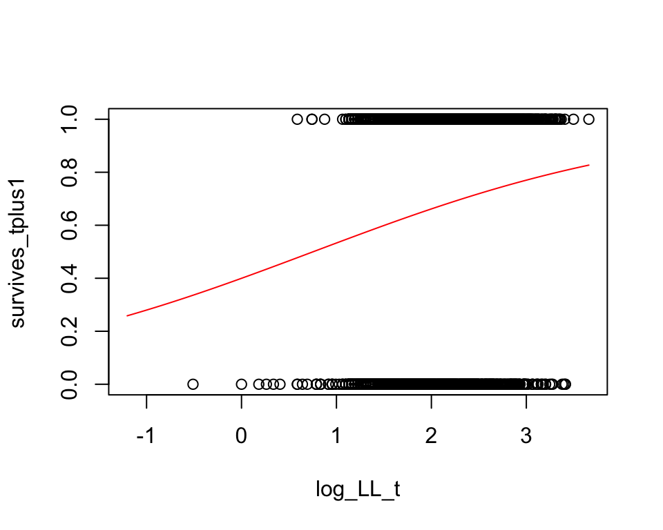

```r
## plot model results
plot(survives_tplus1 ~ log_LL_t, data = survDat)
newdata <- data.frame("log_LL_t" = seq(from = min(survDat$log_LL_t, na.rm = TRUE),
               to = max(survDat$log_LL_t, na.rm = TRUE),
               length.out = 100))
lines(x = newdata$log_LL_t, y = predict(object = survMod, newdata =  newdata, type = "response"), col = "red")
```

**Growth ($G(z',z)$)**

```r
# can use the full dataset
## lm w/ log-transformed size_t and size_t+1
sizeMod <- lm(log_LL_tplus1 ~ log_LL_t , data = dat)
summary(sizeMod)
```

```
##
## Call:
## lm(formula = log_LL_tplus1 ~ log_LL_t, data = dat)
##
## Residuals:
##      Min       1Q   Median       3Q      Max
## -2.61973 -0.33125 -0.02087  0.35263  1.82238
##
## Coefficients:
##             Estimate Std. Error t value Pr(>|t|)
## (Intercept)  0.79604    0.04355   18.28   <2e-16 ***
## log_LL_t     0.55173    0.02050   26.91   <2e-16 ***
## ---
## Signif. codes:  0 '***' 0.001 '**' 0.01 '*' 0.05 '.' 0.1 ' ' 1
##
## Residual standard error: 0.5089 on 2138 degrees of freedom
##   (3112 observations deleted due to missingness)
## Multiple R-squared:  0.253,  Adjusted R-squared:  0.2527
## F-statistic: 724.3 on 1 and 2138 DF,  p-value: < 2.2e-16
```

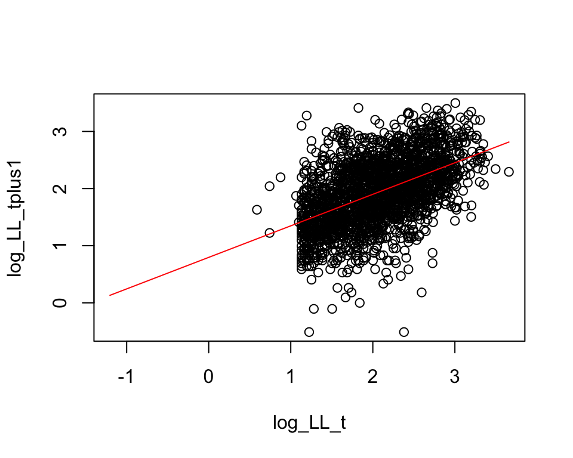

```r
## plot model results
plot(log_LL_tplus1 ~ log_LL_t, data = dat)
newdata <- data.frame("log_LL_t" = seq(from = min(dat$log_LL_t, na.rm = TRUE),
               to = max(dat$log_LL_t, na.rm = TRUE),
               length.out = 100))
lines(x = newdata$log_LL_t, y = predict(object = sizeMod, newdata =  newdata), col = "red")
```

**Number of seeds produced, according to plant size ($b(z)$)**

```r
 ## use only plants that flowered
 seedDat <- dat[dat$flowering==1,]
## fit poisson glm (for count data)
seedMod_t <- MASS::glm.nb(Num_seeds ~ log_LL_t , data = seedDat)
summary(seedMod_t)
```

```
##
## Call:
## MASS::glm.nb(formula = Num_seeds ~ log_LL_t, data = seedDat,
##     init.theta = 2.018311072, link = log)
##
## Deviance Residuals:
##     Min       1Q   Median       3Q      Max
## -3.2573  -0.8830  -0.2820   0.4062   3.5908
##
## Coefficients:
##             Estimate Std. Error z value Pr(>|z|)
## (Intercept)   2.9559     0.2585   11.43   <2e-16 ***
## log_LL_t      1.3321     0.1107   12.03   <2e-16 ***
## ---
## Signif. codes:  0 '***' 0.001 '**' 0.01 '*' 0.05 '.' 0.1 ' ' 1
##
## (Dispersion parameter for Negative Binomial(2.0183) family taken to be 1)
##
##     Null deviance: 726.75  on 547  degrees of freedom
## Residual deviance: 592.19  on 546  degrees of freedom
##   (16 observations deleted due to missingness)
## AIC: 7599.7
##
## Number of Fisher Scoring iterations: 1
##
##
##               Theta:  2.018
##           Std. Err.:  0.114
##
##  2 x log-likelihood:  -7593.731
```

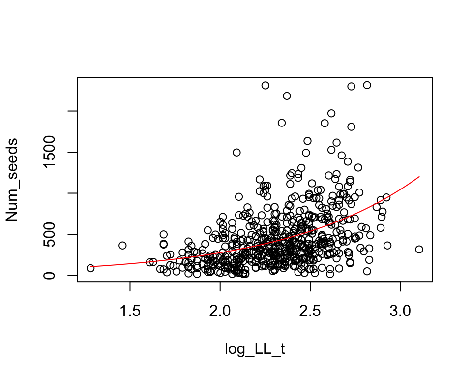

```r
# plot model results
plot(Num_seeds ~ log_LL_t, data = seedDat)
newdata <- data.frame("log_LL_t" = seq(from = min(seedDat$log_LL_t, na.rm = TRUE),
                                       to = max(seedDat$log_LL_t, na.rm = TRUE),
                                       length.out = 100))
lines(x = newdata$log_LL_t, y = predict(object = seedMod_t, newdata =  newdata, type = "response"), col = "red")
```

**Flowering probability ($p_b(z)$)**

```r
## logistic glm with log-transformed size_t
flwrMod_t <- glm(flowering ~ log_LL_t + I(log_LL_t^2) , data = dat, family = binomial)
summary(flwrMod_t)
```

```
##
## Call:
## glm(formula = flowering ~ log_LL_t + I(log_LL_t^2), family = binomial,
##     data = dat)
##
## Deviance Residuals:
##     Min       1Q   Median       3Q      Max
## -0.8037  -0.6158  -0.2286  -0.0249   4.0195
##
## Coefficients:
##               Estimate Std. Error z value Pr(>|z|)
## (Intercept)    -34.020      2.270  -14.99   <2e-16 ***
## log_LL_t        27.670      1.989   13.91   <2e-16 ***
## I(log_LL_t^2)   -5.790      0.432  -13.40   <2e-16 ***
## ---
## Signif. codes:  0 '***' 0.001 '**' 0.01 '*' 0.05 '.' 0.1 ' ' 1
##
## (Dispersion parameter for binomial family taken to be 1)
##
##     Null deviance: 3581.6  on 5249  degrees of freedom
## Residual deviance: 2874.8  on 5247  degrees of freedom
##   (2 observations deleted due to missingness)
## AIC: 2880.8
##
## Number of Fisher Scoring iterations: 8
```

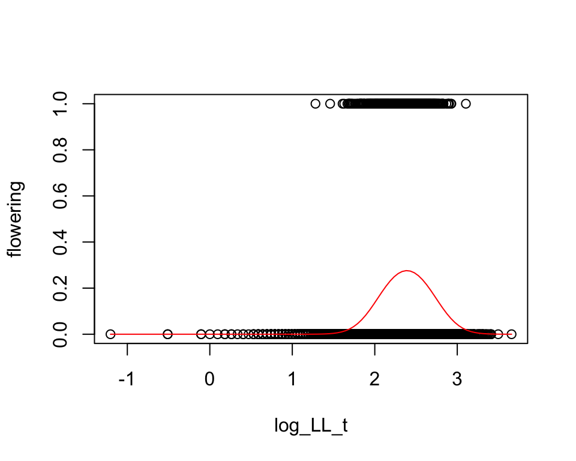

```r
## plot model results
plot(flowering ~ log_LL_t, data = dat)
newdata <- data.frame("log_LL_t" = seq(from = min(dat$log_LL_t, na.rm = TRUE),
                                       to = max(dat$log_LL_t, na.rm = TRUE),
                                       length.out = 100))
lines(x = newdata$log_LL_t, y = predict(object = flwrMod_t, newdata =  newdata, type = "response"), col = "red")
```

**Distribution of recruit size ($c_o(z')$)**

```r
## subset the data
recD <- dat[dat$age == 0 & is.na(dat$age) == FALSE,]

recMod <- lm(log_LL_t ~ 1, data = recD)
summary(recMod)
```

```
##
## Call:
## lm(formula = log_LL_t ~ 1, data = recD)
##
## Residuals:
##      Min       1Q   Median       3Q      Max
## -2.82081 -0.33590 -0.09078  0.23946  1.76075
##
## Coefficients:
##             Estimate Std. Error t value Pr(>|t|)
## (Intercept)  1.61684    0.01064     152   <2e-16 ***
## ---
## Signif. codes:  0 '***' 0.001 '**' 0.01 '*' 0.05 '.' 0.1 ' ' 1
##
## Residual standard error: 0.418 on 1542 degrees of freedom
```

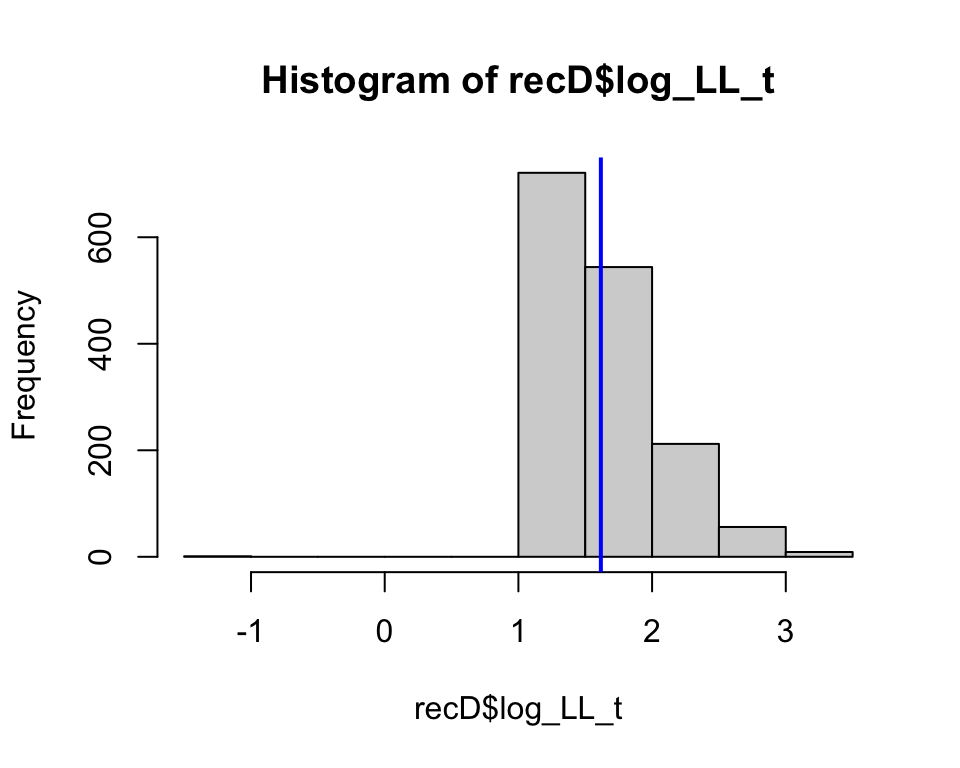

```r
hist(recD$log_LL_t)
abline(v = recMod$coefficients, col = "blue", lwd = 2)
```

**Probability of a seedling in year *t* establishing to a rosette in year *t+1* ($p_{estab}$)**

```r
p.estab.est <- 0.3313
```

**Get germination rate and rate of seed viability maintenance**

```r
## germination rate
germ.rt <- 0.12

## seed viability rate
viab.rt <- 0.57
```

**Probability that a seed from the seedbank in year t will germinate to a seedling in year t+1 ($outSB$)**

```r
outSB.est <-  germ.rt
```

**Probability that a seed from the seedbank in year t will stay in the seedbank in year t+1 ($staySB$)**

```r
staySB.est <- (1-germ.rt)*.9 #estimate that 10% seeds in the SB die from year t to year t+1
```

**Probability that a seed produced by an adult plant in year t will enter the seedbank in year t+1 ($goSB$)**

```r
goSB.est <- viab.rt - germ.rt
```

**Probability that a seed from a plant in year t will go directly to the seedling stage ($goSdlng$)**

```r
goSdlng.est <- germ.rt
```

### Implement the IPM using `ipmr`

**Set up the parameter list**

```r
data_list <- list(
  g_int     = coef(sizeMod)[1],
  g_slope   = coef(sizeMod)[2],
  g_sd      = summary(sizeMod)$sigma,
  s_int     = coef(survMod)[1],
  s_slope   = coef(survMod)[2],
  p_b_int   = coef(flwrMod_t)[1], #probability of flowering
  p_b_slope = coef(flwrMod_t)[2],
  p_b_slope_2 = coef(flwrMod_t)[3],
  b_int   = coef(seedMod_t)[1], #seed production
  b_slope = coef(seedMod_t)[2],
  c_o_mu    = coef(recMod), #recruit size distribution
  c_o_sd    = summary(recMod)$sigma,
  goSdlng   = goSdlng.est, # Probability that non-seedbank seeds will germinate into seedlings in year t+1
  staySB = staySB.est, # Probability that a seed in the seedbank in year t will exit the seedbank in year t+1
  goSB = goSB.est, # probability that a seed produced by an adult plant in year t will enter the seedbank
  outSB = outSB.est, # probability that a seedbank seed will germinate to a seedling in year t+1
  p_estab = p.estab.est # probability that a seedling will establish into a rosette in t+1
)
```

**Set up helper-functions to pass to the model**

```r
inv_logit <- function(lin.pred) {
  1/(1 + exp(-(lin.pred)))
}
```

**Make the IPM kernels**

```r
general_ipm <- init_ipm(sim_gen = "general", # make a general IPM
                        di_dd = "di", # make it density independent
                        det_stoch = "det") %>% # make it deterministic
  define_kernel(

    name          = "P", # growth and survival kernel

    formula       = (1-p_b.) * s. * g. * d_size,

    family        = "CC",

    g.            = dnorm(size_2, g_mu., g_sd),
    g_mu.          = g_int + g_slope * size_1,
    s.            = inv_logit(lin.pred = (s_int + s_slope * size_1)),
    p_b.          = inv_logit(lin.pred = (p_b_int + p_b_slope * size_1 + p_b_slope_2 * I(size_1^2))),
    data_list     = data_list,
    states        = list(c('size')),
    uses_par_sets = FALSE,
    evict_cor     = TRUE,
    evict_fun     = truncated_distributions('norm', 'g.')
) %>%
  define_kernel(

    name          = "leave_seedlings", ## leave seedling stage and go to rosette stage
    formula       = p_estab. * c_o. * d_size,

    family        = 'DC',
    p_estab.      = p_estab,
    c_o.          = dnorm(size_2, c_o_mu, c_o_sd),
    data_list     = data_list,

    states        = list(c('size', "s")),
    uses_par_sets = FALSE,
    evict_cor     = TRUE,
    evict_fun     = truncated_distributions('norm','c_o.')
) %>%
  define_kernel(

    name    = "repro_to_seedlings",

    formula       = (goSdlng) * (p_b. * b. * d_size),

    family        = "CD",

    goSdlng.      = goSdlng.,
    p_b.          = inv_logit(lin.pred = (p_b_int + p_b_slope * size_1 + p_b_slope_2 * size_1^2)),
    b.            = exp(b_int + b_slope * size_1),
    data_list     = data_list,
    states        = list(c('size', 's')),
    uses_par_sets = FALSE,
    evict_cor     = FALSE

) %>%
  define_kernel(

    name          = 'seedbank_to_seedlings',

    formula       = outSB.,

    family        = 'DD',
    outSB.        = outSB,
    data_list     = data_list,

    states        = list(c('b', 's')),
    uses_par_sets = FALSE,
    evict_cor = FALSE

  ) %>%
  define_kernel(

    name    = "stay_seedbank",

    formula       = staySB.,

    family        = "DD",
    staySB.        = staySB,
    data_list     = data_list,
    states        = list(c('b')),
    uses_par_sets = FALSE,
    evict_cor = FALSE

  ) %>%
  define_kernel(

    name          = 'repro_to_seedbank',

    formula       = (goSB.) * (p_b. * b. * d_size),

    family        = 'CD',
    goSB.          = goSB,
    p_b.          = inv_logit(lin.pred = (p_b_int + p_b_slope * size_1 + p_b_slope_2 * size_1^2)),
    b.            = exp(b_int + b_slope * size_1),
    data_list     = data_list,

    states        = list(c('b', 'size')),
    uses_par_sets = FALSE,
    evict_cor = FALSE
)
```

**Define the transitions between kernels**

```r
general_ipm <- general_ipm %>%
  define_impl(
    make_impl_args_list(
      kernel_names = c("P", "leave_seedlings", "repro_to_seedlings", "seedbank_to_seedlings", "stay_seedbank", "repro_to_seedbank"),
      int_rule     = c(rep("midpoint", 6)),
      state_start    = c('size', "s", "size", "b", "b", "size"),
      state_end      = c("size", "size", "s", "s", "b", "b")
    )
  )
```

**Define the limits of size and starting population states**

```r
# lower limit of size
L <- -0.9
# upper limit of size
U <- 4.4
# number of break-points
n <- 500

set.seed(2312)

init_pop_vec   <- runif(500) # initial vector for the continuous stage population

init_seed_bank <-  17144 # average estimated seedbank size / plot

init_seedlings <- 86 # average estimated number of seedlings/plot
```

**Run the IPM**

```r
general_ipm <- general_ipm %>%
  define_domains(

    # We can pass the variables we created above into define_domains

    size = c(L, U, n),

  ) %>%
  define_pop_state(

    # We can also pass them into define_pop_state

    pop_vectors = list(
      n_size = init_pop_vec,
      n_b  = init_seed_bank,
      n_s  = init_seedlings
    )
  ) %>%
  make_ipm(iterations = 100,
           usr_funs = list(inv_logit   = inv_logit), return_main_env = TRUE )
```

### Visualize the IPM kernel

```r
## make an image of the IPM
## first have to make a mega-kernel
mega_mat <- make_iter_kernel(ipm = general_ipm,
                             mega_mat = c(stay_seedbank, 0, repro_to_seedbank, seedbank_to_seedlings, 0, repro_to_seedlings, 0, leave_seedlings, P),
                               )
## check to make sure I constructed the mega-kernel correctly (should be nearly equal values)
Re(eigen(mega_mat[[1]])$values[1]) - lambda(general_ipm)
```

```
##       lambda
## 1.110223e-15
```

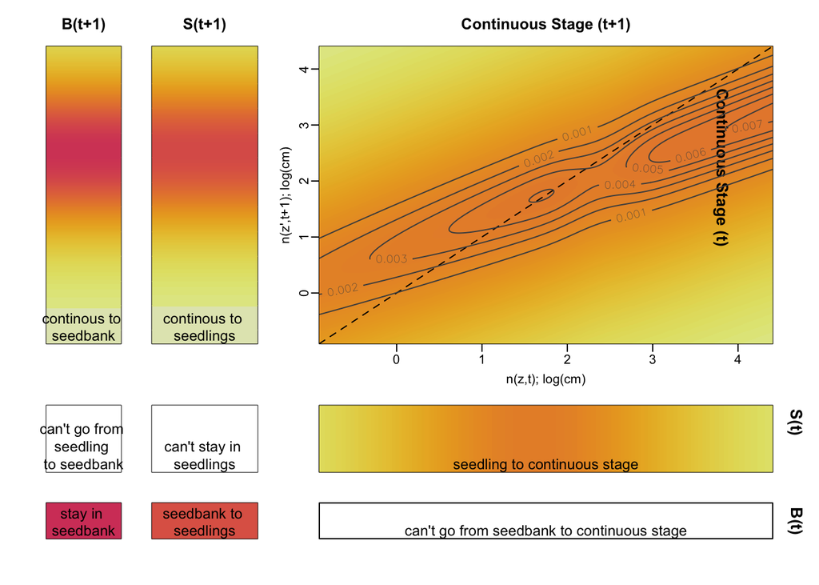

```r
## visualize the full kernel
## define the meshpoints
meshpts <- seq(from = L, to = U, length = 500)
## set up the palette
pal <- hcl.colors(n = 100, palette = "Heat 2", rev = TRUE)
## plot the continuous part of the kernel (leave out first two rows and cols that correspond to the discrete stages)

## make the entire figure--lattice plot?
graphics::layout(mat = matrix(c(1,4, 7, 2, 5, 8, 3, 6, 9),nrow = 3, ncol = 3), widths = c(1.5,1.5,6),heights = c(6,1.5,1.5))
## B(t+1)
par(mar = c(3,3,3,1))
image(t(mega_mat$mega_matrix[1,3:502]^.1), xaxt = "n", yaxt = "n",
      main = "B(t+1)",
      col = pal[(round(min((mega_mat$mega_matrix[1,3:502])^.1),2)*100):
                  (round(max((mega_mat$mega_matrix[1,3:502])^.1),2)*100)])
mtext(side = 1, text  = c("continous to \nseedbank"), line = -1, cex = .75)
## S(t+1)
par(mar = c(3,1,3,1))
image(t(mega_mat$mega_matrix[2,3:502]^.1), xaxt = "n", yaxt = "n",
      main = "S(t+1)",
      col = pal[(round(min((mega_mat$mega_matrix[2,3:502])^.1),2)*100):
                  (round(max((mega_mat$mega_matrix[2,3:502])^.1),2)*100)])
mtext(side = 1, text  = c("continous to \nseedlings"), line = -1, cex = .75)
## K matrix
par(mar = c(3,3,3,3)
    ,mgp = c(1.75,.5,0)
    )
image(x = meshpts, y = meshpts, t(mega_mat$mega_matrix[3:502,3:502])^.1,
      xlab = "n(z,t); log(cm)", ylab = "n(z',t+1); log(cm)",
      main = "Continuous Stage (t+1)",
      col = pal[(round(min( t(mega_mat$mega_matrix[3:502,3:502])^.1),2)*100): (round(max( t(mega_mat$mega_matrix[3:502,3:502])^.1),2)*100)]
      ) ## get the correct values for the color ramp that correspond to the actual probabilities in the entire matrix
text(x = 3.8, y = 2.25, c("Continuous Stage (t)"), xpd = NA, srt = -90, cex = 1.25, font = 2)
abline(a = 0, b = 1, lty = 2)
contour(x = meshpts, y = meshpts,
        t(mega_mat$mega_matrix[3:502,3:502]),
        add = TRUE, drawlabels = TRUE, nlevels = 10, col = "grey30")
# seedlings to seedbank
par(mar = c(1,3,1,1))
image(as.matrix(0), xaxt = "n", yaxt = "n", col = "white")
mtext(side = 1, text  = c("can't go from \nseedling \nto seedbank"), line = -1, cex = .75)
# seedlings to seedlings
par(mar = c(1,1,1,1))
image(as.matrix(0), xaxt = "n", yaxt = "n",  col = "white")
mtext(side = 1, text  = c("can't stay in \nseedlings"), line = -1, cex = .75)
#S(t)
par(mar = c(1,3,1,3))
image(as.matrix(mega_mat$mega_matrix[3:502,2]^.1), yaxt = "n", xaxt = "n",
        col = pal[(round(min( t(mega_mat$mega_matrix[3:502,2])^.1),2)*100):
                    (round(max( t(mega_mat$mega_matrix[3:502,2])^.1),2)*100)])
text(x = 1.05,y = .5, c("S(t)"), xpd = NA, srt = -90, cex = 1.25, font = 2)
mtext(side = 1, text  = c("seedling to continuous stage"), line = -1, cex = .75)
## plot the staySB probability
par(mar = c(3,3,1,1))
image(as.matrix(mega_mat$mega_matrix[1,1]^.1), xaxt = "n", yaxt = "n",
      col = pal[round(max(mega_mat$mega_matrix[1,1]^.1),2)*100])
mtext(side = 1, text  = c("stay in \nseedbank"), line = -1, cex = .75)
## plot the seedbank to seedlings probability
par(mar = c(3,1,1,1))
image(as.matrix(t(mega_mat$mega_matrix[2,1])^.1), xaxt = "n", yaxt = "n",
      col = pal[round(max(t(mega_mat$mega_matrix[2,1])^.1),2)*100])
mtext(side = 1, text = c("seedbank to \nseedlings"), line = -1, cex = .75)
## B(t)(is all zeros--can't transition to continuous stage from the seedbank)
par(mar = c(3,3,1,3))
image(t(mega_mat$mega_matrix[3:502,1]^.1), yaxt = "n", xaxt = "n",
        col = pal[(round(min( t(mega_mat$mega_matrix[3:502,1])^.1),2)*100):
                    (round(max( t(mega_mat$mega_matrix[3:502,1])^.1),2)*100)])
text(x = 1.1,y = .5, c("B(t)"), xpd = NA, srt = -90, cex = 1.25, font = 2)
mtext(side = 1, text = c("can't go from seedbank to continuous stage"), line = -1, cex = .75)
```